# Reproducible Research Assignment 1

Peter Cross

Sunday, February 28, 2016

```r
library(dplyr)
library(lattice)
```

## Loading and preprocessing the data

Set the working directory to where the activity data is located

```r
setwd("c:/Users/peter/Downloads/repdata-data-activity/")
```

Read in the data

```r
activity <- read.csv("activity.csv")
```

Aggregate step data into daily levels, generate historgram and rug

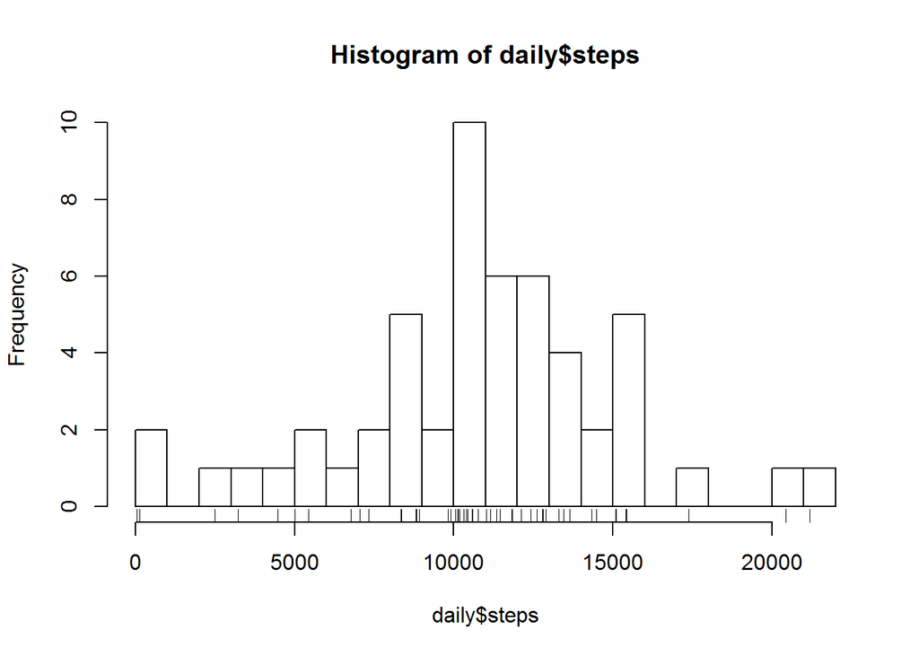

```r
daily <- aggregate(steps ~ date, data=activity,FUN=sum, na.rm=TRUE)
hist(daily$steps,breaks=25)
rug(daily$steps)
```

## What is mean total number of steps taken per day?

Determine Median and Mean for daily step levels, removing NA values

```r
step.median <- median(daily$steps,na.rm=TRUE)
step.median
```

```
## [1] 10765
```

```r
step.mean <- mean(daily$steps,na.rm=TRUE)
step.mean
```

```
## [1] 10766.19
```

## What is the average daily activity pattern?

Determine the Hourly means across the days, and plot the line graph

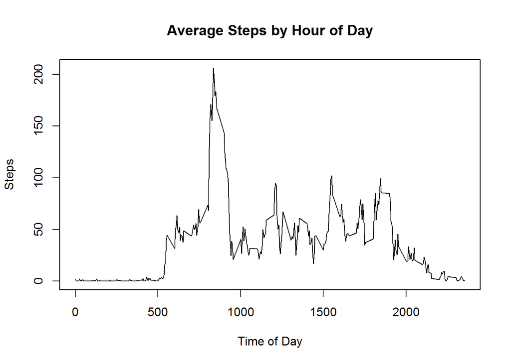

```r
hourly <- aggregate(steps ~ interval,data=activity,FUN=mean,na.rm=TRUE)
plot(hourly$steps ~ hourly$interval,type="l",xlab="Time of Day",ylab="Steps",main="Average Steps by Hour of Day")
```

determine the period of maximum mean steps

```r
max.hour <- subset(hourly,hourly$steps == max(hourly$steps))
max.hour$interval
```

```
## [1] 835
```

## Imputing missing values

Determine the count of NA readings

```r
sum(is.na(activity$steps))
```

```
## [1] 2304
```

Determine the median steps for each interval

```r
median.interval <- aggregate(steps ~ interval,data=activity,FUN=median,na.rm=TRUE)
```

Append the median step level for each interval

```r
activity2 <- merge(activity,median.interval,by="interval",all.x=TRUE)
```

Determine positions of NA values in original dataset

```r
na.count <- is.na(activity2$steps.x)
```

replace any NA values in origianl data with median values for that interval

```r
activity2$steps.x[na.count] <- activity2$steps.y[na.count]
```

remove extraneous columns

```r
activity2 <- select(activity2,steps = steps.x,date,interval)
```

determine the new Histogram, daily values, and median and means for comparison

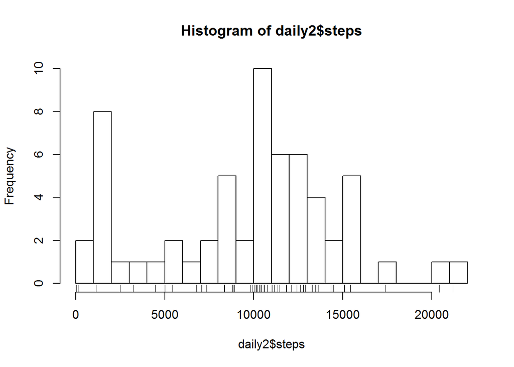

```r
daily2 <- aggregate(steps ~ date, data=activity2,FUN=sum, na.rm=TRUE)
hist(daily2$steps,breaks=25)
rug(daily2$steps)
```

```r
step.mean2 <- mean(daily2$steps)
step.median2 <- median(daily2$steps)
step.mean2
```

```
## [1] 9503.869
```

```r
step.median2
```

```
## [1] 10395
```

Compare the mean and median differences between datasets with NA values removed and NA values replaced.

```r
mean.diff <- step.mean - step.mean2
median.diff <- step.median - step.median2
mean.diff
```

```
## [1] 1262.32
```

```r
median.diff
```

```
## [1] 370
```

## Are there differences in activity patterns between weekdays and weekends?

Append a factor column for weekend/weekday

```r
activity2$date <- as.POSIXct(activity2$date,format='%Y-%m-%d')
activity2 <- mutate(activity2,"day_type" = as.factor(ifelse(weekdays(date) == "Saturday" | weekdays(date) == "Sunday","weekend","weekday")))
```

find means for each of the day types by interval and graph them

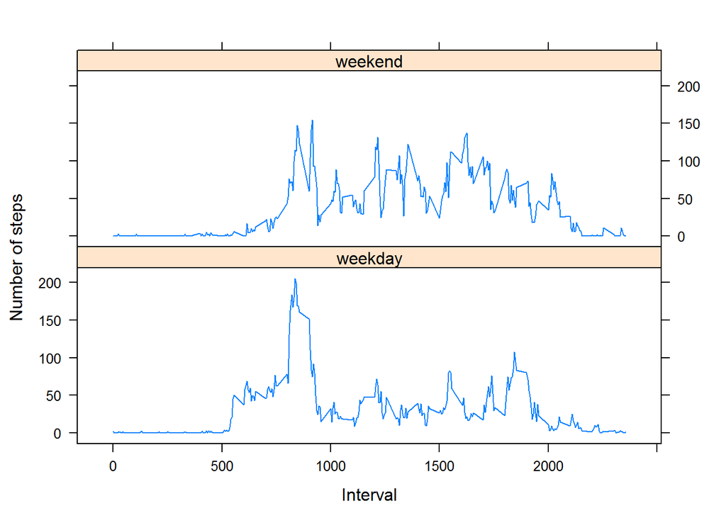

```r
#par(mfcol=c(2,1))
act2_mean <- aggregate(activity2$steps,by=list(activity2$interval,activity2$day_type),FUN=mean)
names(act2_mean) <- c("interval","day_type","steps")
xyplot(steps ~ interval | day_type,act2_mean,type="l",lwd=1,xlab="Interval",ylab="Number of steps",layout=c(1,2))
```